# Intro to RNA-seq Analysis

## Step V - DESeq2

`DESeq2` is an R package that allows differential expression analysis.

To run `DESeq2`, you will need two key inputs:

- Gene count matrix (i.e., read counts for each gene) (featureCounts output)
- Sample information file (metadata.csv)

You will also need to define the type of contrasts/design for the analysis.

For example, suppose we have the following metadata for a dataset:

| sample | replicate | genotype | treatment | grp |
| --- | --- | --- | --- | --- |
| wt_1 | 1 | wild-type | ctrl | wt_ctrl |
| wt_2 | 2 | wild-type | ctrl | wt_ctrl |
| wt_3 | 1 | wild-type | inhibitor | wt_inhib |
| wt_4 | 2 | wild-type | inhibitor | wt_inhib |
| mut_1 | 1 | mutant | ctrl | mut_ctrl |
| mut_2 | 2 | mutant | ctrl | mut_ctrl |
| mut_3 | 1 | mutant | inhibitor | mut_inhib |
| mut_4 | 2 | mutant | inhibitor | mut_inhib |

We can run the following contrasts:

**Contrasts**

- contrast = ~ genotype
- contrast = ~ treatment
- contrast = ~ genotype + treatment + genotype:treatment
- contrast = ~ grp

**Comparisons**

- Compares wild-type vs mutant (irrrespective of treatment)
- Compares ctrl vs inhibitor (irrespective of genotype)
- Compares genotype + treatment and their interactions
- Compares wt_ctrl vs wt_inhib, wt_ctrl vs mut_ctrl, wt_ctrl vs mut_inhib
- Job submission

```bash
sbatch code/DESeq2.sh
```

## Step V - DESeq2 (pre-processing output)

The custom `DESeq2` script generates several plots, tables, and genelists organized into the following directories.

```bash
analysis/deseq2
├── genelists
└── plots
```

Lets examine some of the pre-processing information about the dataset.

- Library size
- Count distribution
- Correlation heatmap
- PCA

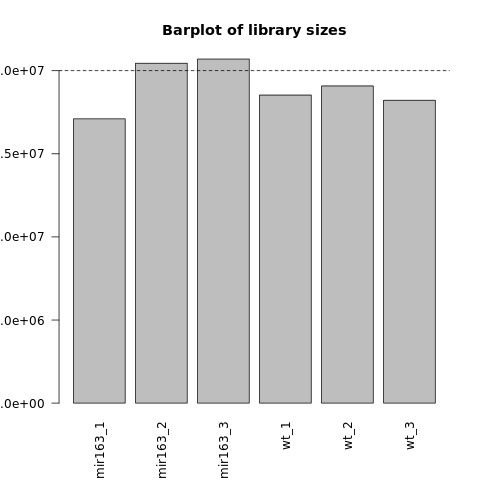

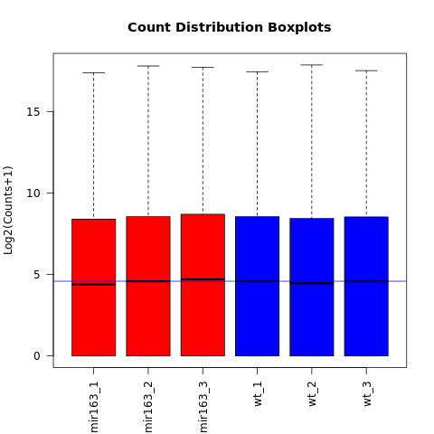

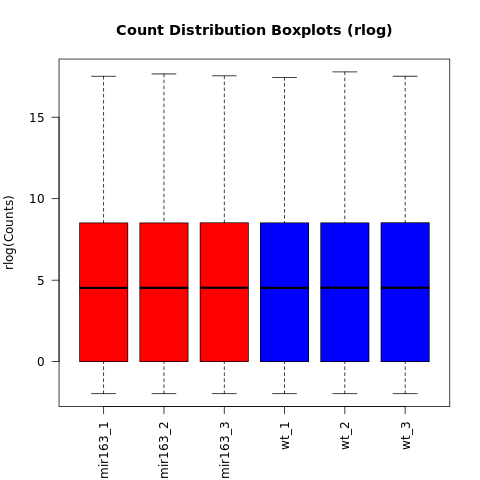

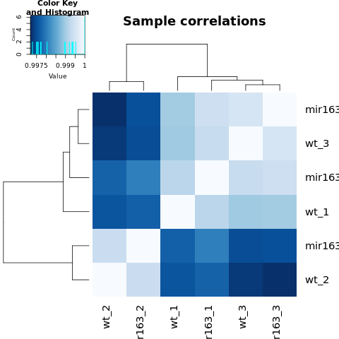

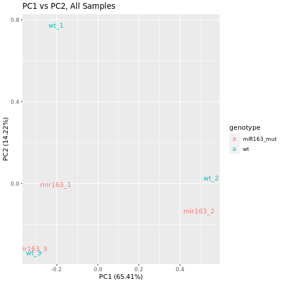

## Step V - DESeq2 (DEG output)

DEGs are defined using two filters:

- log2foldchange > 0, FDR (adjusted-pvalue) < 0.1
- log2foldchange > 1, FDR < 0.05

```bash
$ ls analysis/deseq2/genelists
DESeq2.DEG_summary.txt
DESeq2_normalizedcounts.txt
genotype_miR163_mut_vs_wt_DEGs.LFC0_p1.txt
genotype_miR163_mut_vs_wt_DEGs.LFC1_p05.txt
```

- Summary table
- Volcano plot (p < 0.1, l2fc > 0)
- Volcano plot (p < 0.05, l2fc > 1)

| Comparison | Total DEGs (p < 0.1) | Up DEGs (p < 0.1, LFC > 0) | Down DEGs (p < 0.1, LFC < 0) | Total DEGs (p < 0.05) | Up DEGs (p < 0.05, LFC > 1) | Down DEGs (p < 0.05, LFC < -1) |
| --- | --- | --- | --- | --- | --- | --- |
| genotype_miR163_mut_vs_wt | 11 | 6 | 5 | 5 | 3 | 2 |

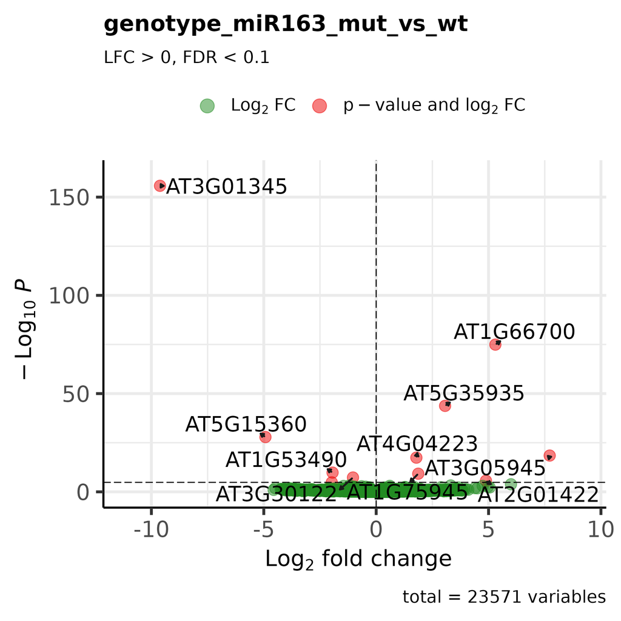

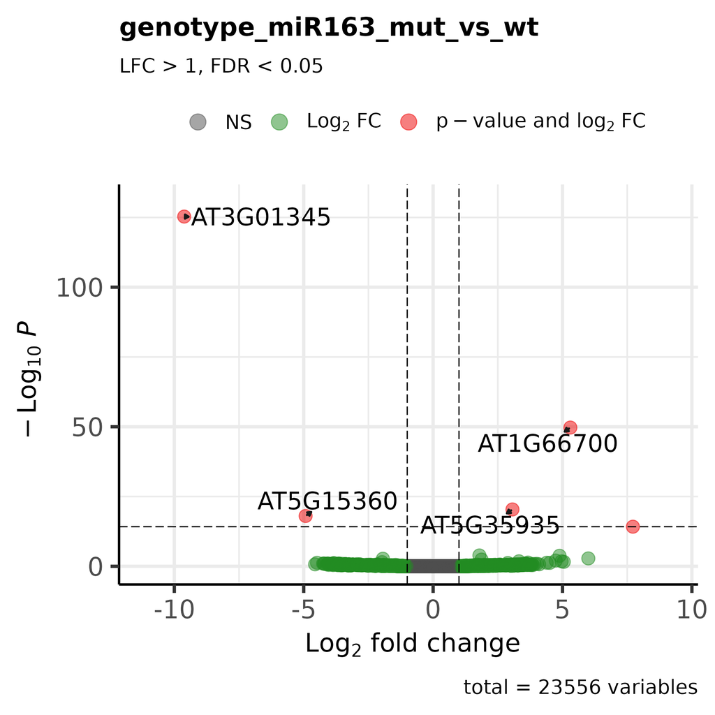

## Step VI - MultiQC

`MultiQC` is used to generate a summary of the raw and processed data. The program aggregates all the log files from different programs (e.g., trim_galore, STAR) and provide a summary HTML file.

- Job submission

```bash
sbatch code/multiqc.sh
```

## Step VII - Visualization with IGV

To inspect and examine your RNA-seq results, you can load the **BigWig** or **BAM** files into IGV.

Download the `.bam`, `.bam.bai`, and `.bw` files. The `.bam` files are quite large (> 1Gb) whereas the `.bw` files are smaller (Mb). These files can be loaded into IGV for visualization and inspection.

**Show IGV demonstration**

## Workflow Cheatsheet

You can follow this cheatsheet to run the workflow.

## Feedback

Please take a few minutes to provide feedback for this workshop by filling out the workshop survey.

All repsonses are anonymous and will help to improve future workshops and training.

[Survey link](https://bit.ly/4062Wij)